# Lecture 30: Sample Size

Associated Textbook Sections: [14.6](https://ccsf-math-108.github.io/textbook/chapters/14/6/Choosing_a_Sample_Size.html)

## Outline

- Confidence Intervals
- Sample Proportions

## Set Up the Notebook

```python
from datascience import *
import numpy as np
%matplotlib inline
import matplotlib.pyplot as plt
plt.style.use('fivethirtyeight')
```

## Confidence Intervals

### Graph of the Distribution

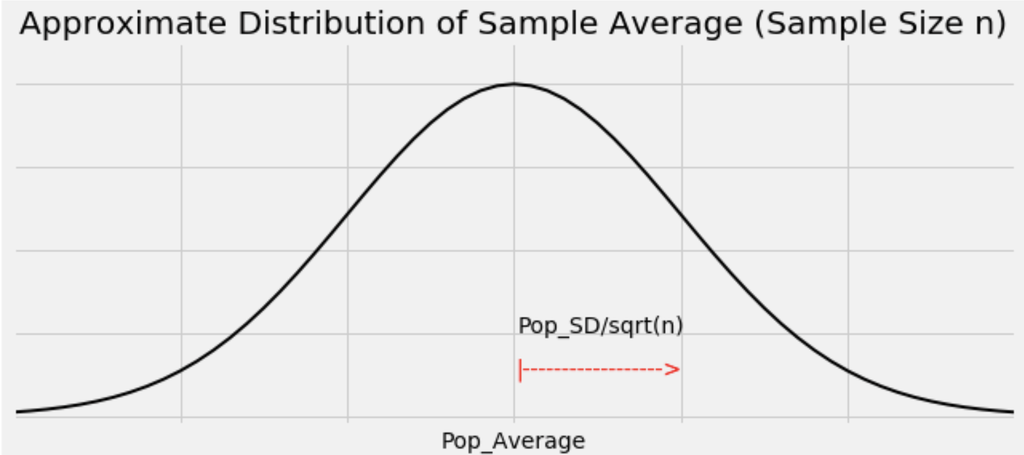

### The Key to 95% Confidence

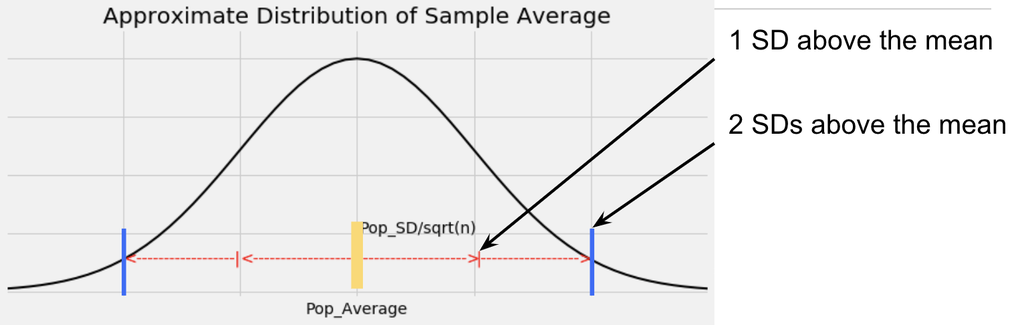

- For about 95% of all samples, the sample average and population average are within 2 SDs of each other.
- SD = SD of sample average = $(\text{population SD}) / \sqrt{\text{sample size}}$

### Constructing the Interval

For about 95% of all samples,

- If you stand at the population average and look two SDs on both sides, you will find the sample average.
- Distance is symmetric.
- So if you stand at the sample average and look two SDs on both sides, you will capture the population average.

### The Interval

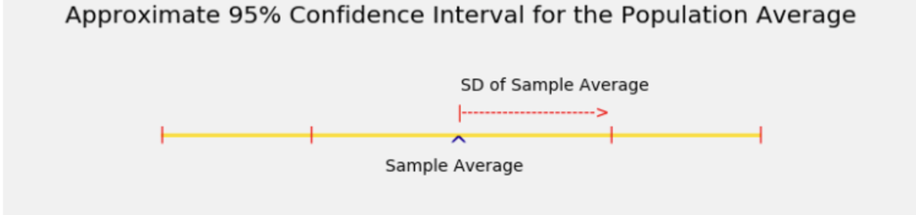

### Width of the Interval

Total width of a 95% confidence interval for the population average

- $= 4 * \text{SD of the sample average}$
- $= 4 * (\text{population SD}) / \sqrt{\text{sample size}}$
- The $\text{population SD}$ is unknown in practice...

## Sample Proportions

### Proportions are Averages

- Data: 1 1 1 1 0 0 0 0 0 0 (10 entries)
  - Sum = 4 (number of 1's)
  - Average = 4/10 = 0.4 (proportion of 1's)
- If the population consists of 1's and 0's (yes/no answers to a question), then:
  - the population average is the proportion of 1's in the population
  - the sample average is the proportion of 1's in the sample

```python
number_of_ones = 4
zero_one_population = np.append(np.ones(number_of_ones),
                                np.zeros(10 - number_of_ones))
zero_one_population
```

```
array([ 1.,  1.,  1.,  1.,  0.,  0.,  0.,  0.,  0.,  0.])
```

```python
np.mean(zero_one_population)
```

```
0.40000000000000002
```

### Confidence Interval

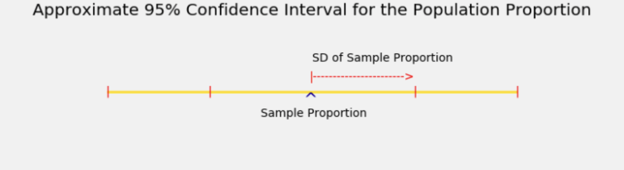

### Controlling the Width

- Total width of an approximate 95% confidence interval for a population proportion is equal to

$$\text{width of 95\% confidence interval} = 4 * \left(\frac{\text{SD of 0/1 population}}{\sqrt{\text{sample size}}}\right)$$

- The narrower the interval, the more precise your estimate.
- Suppose you want the total width of the interval to be no more than 1%. How should you choose the sample size?

### The Sample Size for a Given Width

- From Formula: $0.01 = 4 * \left(\frac{\text{SD of 0/1 population}}{\sqrt{\text{sample size}}}\right)$
  - Left side: 1%, the max total width that you'll accept
  - Right side: formula for the total width
- Re-arrange: $\sqrt{\text{sample size}} = 4 * \left(\frac{\text{SD of 0/1 population}}{0.01}\right)$
- Result: $\text{sample size} = \left(4 * \left(\frac{\text{SD of 0/1 population}}{0.01}\right)\right)^2$

### Demo: SD of 0/1 Population

- Calculate the SD of the 0/1 population
- Make a graph with proportion of ones on the x axis and SD on the y axis.

```python
zero_one_population
```

```
array([ 1.,  1.,  1.,  1.,  0.,  0.,  0.,  0.,  0.,  0.])
```

```python
np.std(zero_one_population)
```

```
0.48989794855663565
```

```python
def sd_of_zero_one_population(number_of_ones):
    """
    SD of a population with num_ones ones
    and (10 - num_ones) zeros
    """
    zero_one_population = np.append(np.ones(number_of_ones),
                                    np.zeros(10 - number_of_ones))
    return np.std(zero_one_population)
```

```python
possible_oness = np.arange(11)
zero_one_pop = Table().with_columns(
    'Number of ones', possible_oness,
    'Proportion of ones', possible_oness / 10
)
```

```python
possible_oness
```

```
array([ 0,  1,  2,  3,  4,  5,  6,  7,  8,  9, 10])
```

```python
sds = zero_one_pop.apply(sd_of_zero_one_population, 'Number of ones')
zero_one_pop = zero_one_pop.with_column('SD', sds)
```

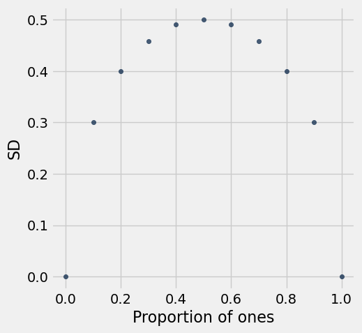

```python
zero_one_pop.scatter('Proportion of ones', 'SD')
```

### "Worst Case" Population SD

- $\sqrt{\text{sample size}} = 4 * \left(\frac{\text{SD of 0/1 population})}{0.01}\right)$
- SD of 0/1 population **is at** most 0.5
- $\text{sample size} \geq \left(4 * \left(\frac{0.5}{0.01}\right)\right)^ 2 = 40000$
- The sample size should be 40,000 or more

### Demo: CI Width

[figure not shown]

- A researcher is estimating a population proportion based on a random sample of size 1,004.
- With chance at least 95%, the estimate will be correct to within 3%.
- A 3% margin of error translates to an interval width of 6%.

```python
CI_width = 4 * 0.5 / np.sqrt(1004)
CI_width
```

```
0.063119440309780311
```

### Demo: Margin of Error

- A researcher is estimating a population proportion based on a random sample of size 10,000.
- With a confidence level of 95%, the estimate will be correct to within how many percentage points?

```python
width = 4 * 0.5 / np.sqrt(10000)
margin_of_error = width / 2
margin_of_error_percent = margin_of_error * 100
margin_of_error_percent
```

```
1.0
```

### Demo: Sample Size

- I am going to use a 68% confidence interval to estimate a population proportion.
- I want the total width of my interval to be no more than 2.5%.
- How large must my random sample be?
- $2 \cdot \left(\frac{0.5}{\sqrt{\text{sample\_size}}}\right) = 0.025$
- In other words: $\text{sample\_size} = \left(2 * \left(\frac{0.5}{0.025}\right)\right)^2$

```python
sample_size = (2 * 0.5 / 0.025) ** 2
sample_size
```

```
1600.0
```

## Attribution

This content is licensed under the Creative Commons Attribution-NonCommercial-ShareAlike 4.0 International License (CC BY-NC-SA 4.0) and derived from the Data 8: The Foundations of Data Science offered by the University of California, Berkeley.